# From zero to hero: raw data to mapped networks - 2 Statistics

##### Check out the [user manual](https://creativedatasolutions.github.io/dave.docs/partial/stats.html) for more details about this module’s features.

## Two-class comparison of means

##### Identify significant differences between groups. Use the statistics >> two-class to carry out a non-parametric test to identify significant difference for the `class` factor which corresponds to diabetic or non-diabetic samples.

### Methods

##### Use the design menu to select a two-class factor identifying groups to test for differences.

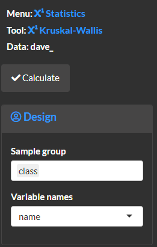

##### Use the filter menu to optionally only keep significant results. The example shows how to select comparison which display false discovery rate adjusted p-values less than or equal to 0.05.

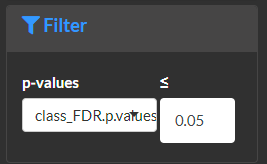

##### Select `calculate` and view the statistical analysis methods and results.

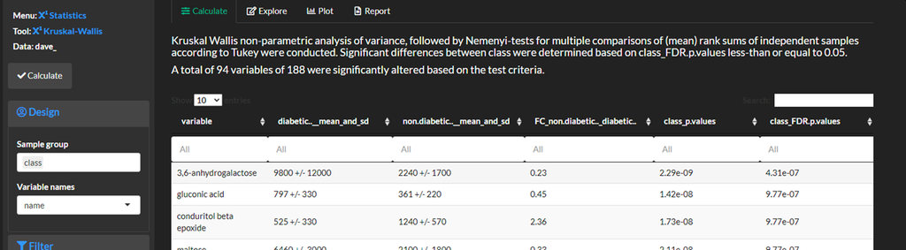

### Explore and plot

##### Create a volcano plot to display significantly altered variables p-values vs. the fold change in `class` means.

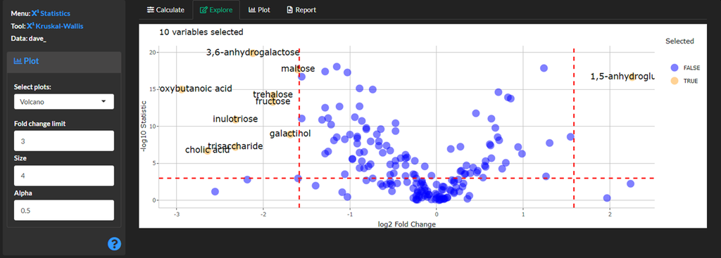

##### Optionally create violin plots to view the class distributions for select variables. Note only the plot option allows plotting of multiple variables which will be shown in the report.

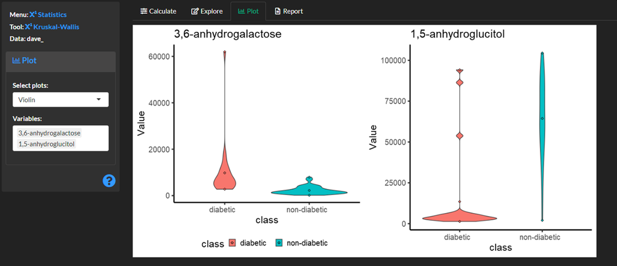

### Report

##### Create a report capturing the methods results and figures.

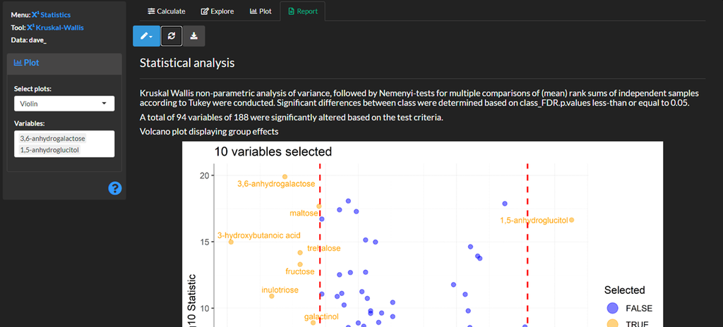

### Save

##### Save the results for later analyses. Optionally remove any variables not meeting the significance cutoff from the data set (`keep selected`).

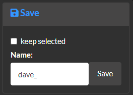